# Boosted Decision Trees by AI

# Data Preparation

```r
# Load required libraries
library(tidyverse)
library(caTools)
library(rpart)
library(rpart.plot)
library(caret)
library(Boruta)
library(cvms)
library(dplyr)
library(caret)
library(kableExtra)
library(gridExtra)
```

```r
# Load training data
flight_data_train <- read_csv("~/FlightProject/flight_data_train.csv") %>%
  as.data.frame() %>%
  select(-data_set_division)

# Load test data
flight_data_test <- read_csv("~/FlightProject/flight_data_test.csv") %>%
  as.data.frame()%>%
  select(-data_set_division)

# Display training data structure
glimpse(flight_data_train)
```

```
Rows: 8,477
Columns: 26
$ Airline                  <chr> "IndiGo", "IndiGo", "SpiceJet", "Jet Airways"…
$ Date_of_Journey          <chr> "12/05/2019", "01/03/2019", "24/06/2019", "12…
$ departure_date_time      <dttm> 2019-05-12 18:05:00, 2019-03-01 16:50:00, 20…
$ Departure_Day            <dbl> 12, 1, 24, 12, 1, 27, 1, 18, 24, 3, 15, 12, 1…
$ Departure_Month          <dbl> 5, 3, 6, 3, 3, 5, 6, 4, 6, 3, 4, 6, 6, 5, 3, …
$ Departure_Year           <dbl> 2019, 2019, 2019, 2019, 2019, 2019, 2019, 201…
$ Departure_Time           <time> 18:05:00, 16:50:00, 09:00:00, 18:55:00, 08:0…
$ arrival_date_time        <dttm> 2019-05-12 23:30:00, 2019-03-01 21:35:00, 20…
$ Arrival_Day              <dbl> 12, 1, 24, 13, 2, 27, 1, 18, 24, 4, 15, 13, 1…
$ Arrival_Month            <dbl> 5, 3, 6, 3, 3, 5, 6, 4, 6, 3, 4, 6, 6, 5, 3, …
$ Arrival_Time             <time> 23:30:00, 21:35:00, 11:25:00, 10:25:00, 05:0…
$ Duration                 <chr> "5h 25m", "4h 45m", "2h 25m", "15h 30m", "21h…
$ Source                   <chr> "Kolkata", "Banglore", "Kolkata", "Banglore",…
$ Destination              <chr> "Banglore", "Delhi", "Banglore", "Delhi", "De…
$ airport_code_departure   <chr> "CCU", "BLR", "CCU", "BLR", "BLR", "DEL", "DE…
$ airport_code_first_stop  <chr> "NAG", "NAG", NA, "BOM", "BOM", "BOM", "BLR",…
$ airport_code_second_stop <chr> NA, NA, NA, NA, NA, NA, NA, NA, NA, "BOM", NA…
$ airport_code_third_stop  <chr> NA, NA, NA, NA, NA, NA, NA, NA, NA, NA, NA, N…
$ airport_code_arrival     <chr> "BLR", "DEL", "BLR", "DEL", "DEL", "COK", "CO…
$ Route                    <chr> "CCU → NAG → BLR", "BLR → NAG → DEL", "CCU → …
$ Total_Stops              <chr> "1 stop", "1 stop", "non-stop", "1 stop", "1 …
$ Price                    <dbl> 6218, 13302, 3873, 11087, 22270, 8625, 8907, …
$ Additional_Info          <chr> "No info", "No info", "No info", "In-flight m…
$ departure_day_of_week    <chr> "Sunday", "Friday", "Monday", "Tuesday", "Fri…
$ Departure_Hour           <dbl> 18, 16, 9, 18, 8, 11, 9, 20, 11, 16, 8, 14, 2…
$ Duration_Hours           <dbl> 5.416667, 4.750000, 2.416667, 15.500000, 21.0…
```

Replacing the missing values for airport stops with NONE.

```r
flight_data_train <- flight_data_train %>%
  mutate(
    # Replace missing airport stops with "NONE"
    airport_code_first_stop = ifelse(is.na(airport_code_first_stop), "NONE", airport_code_first_stop),
    airport_code_second_stop = ifelse(is.na(airport_code_second_stop), "NONE", airport_code_second_stop),
    airport_code_third_stop = ifelse(is.na(airport_code_third_stop), "NONE", airport_code_third_stop)
  )

flight_data_test <- flight_data_test %>%
  mutate(
    # Replace missing airport stops with "NONE"
    airport_code_first_stop = ifelse(is.na(airport_code_first_stop), "NONE", airport_code_first_stop),
    airport_code_second_stop = ifelse(is.na(airport_code_second_stop), "NONE", airport_code_second_stop),
    airport_code_third_stop = ifelse(is.na(airport_code_third_stop), "NONE", airport_code_third_stop)
  )
```

Feature Engineering

```r
# Create engineered features for training data
flight_data_train_processed <- flight_data_train %>%
  mutate(
    # Convert categorical stops to numeric feature
    number_of_stops = case_when(
      Total_Stops == "non-stop" ~ 0,
      Total_Stops == "1 stop" ~ 1,
      Total_Stops == "2 stops" ~ 2,
      Total_Stops == "3 stops" ~ 3,
      Total_Stops == "4 stops" ~ 4
    ),
    # Create weekend indicator feature
    weekend = case_when(
      departure_day_of_week %in% c("Sunday", "Saturday") ~ "Weekend",
      TRUE ~ "Weekday"
    )
  )

# Apply same transformations to test data
flight_data_test_processed <- flight_data_test %>%
  mutate(
    number_of_stops = case_when(
      Total_Stops == "non-stop" ~ 0,
      Total_Stops == "1 stop" ~ 1,
      Total_Stops == "2 stops" ~ 2,
      Total_Stops == "3 stops" ~ 3,
      Total_Stops == "4 stops" ~ 4
    ),
    weekend = case_when(
      departure_day_of_week %in% c("Sunday", "Saturday") ~ "Weekend",
      TRUE ~ "Weekday"
    )
  )

flight_data_train_processed <- flight_data_train_processed %>%
  select(Departure_Day, Departure_Month, Departure_Hour, Duration_Hours,
             number_of_stops, weekend, Date_of_Journey, departure_date_time,
             arrival_date_time, Airline, airport_code_arrival,
             airport_code_departure, airport_code_first_stop,
             airport_code_second_stop, airport_code_third_stop, Price)

flight_data_test_processed <- flight_data_test_processed %>%
  select(Departure_Day, Departure_Month, Departure_Hour, Duration_Hours,
             number_of_stops, weekend, Date_of_Journey, departure_date_time,
             arrival_date_time, Airline, airport_code_arrival,
             airport_code_departure, airport_code_first_stop,
             airport_code_second_stop, airport_code_third_stop, Price)
```

# Initial GenAI Prompt

Hey Gemini! I’m learning data science and this week I’m working on decision trees. Can you help me write the R code to make this a boosted decision tree?

`Deep Decision Tree (optimal complexity)`

`model_deep <- rpart(Price ~ Departure_Day + Departure_Month + Departure_Hour + Duration_Hours + number_of_stops + weekend + Date_of_Journey + departure_date_time + arrival_date_time + Airline + airport_code_arrival + airport_code_departure + airport_code_first_stop + airport_code_second_stop + airport_code_third_stop, data = flight_data_train_processed, method = "anova", minsplit = 8, minbucket = 2, maxdepth = 30)`

# Gemini Response

This script demonstrates how to build a boosted decision tree model using the ‘xgboost’ package in R.

This code sets up a basic boosted model. The key is that it trains many simple trees instead of one complex one, with each tree learning from the errors of the previous ones. A great next step would be to experiment with different xgboost parameters like nrounds, max.depth, and eta to find the optimal combination for your dataset. You could also compare the performance of this model to your original rpart model using metrics like RMSE or MAE.

## Step 1: Install and load the ‘xgboost’ package.

If you don’t have it installed, run the following line: install.packages(“xgboost”)

```r
library(xgboost)
```

## Step 2: Prepare the data for xgboost.

The ‘xgboost’ library requires the data to be in a matrix format. We will separate the target variable (Price) from the predictor variables.

Define the predictor variables (features).

```r
features <- c("Departure_Day", "Departure_Month", "Departure_Hour", "Duration_Hours",
             "number_of_stops", "weekend", "Date_of_Journey", "departure_date_time",
             "arrival_date_time", "Airline", "airport_code_arrival",
             "airport_code_departure", "airport_code_first_stop",
             "airport_code_second_stop", "airport_code_third_stop")
```

Separate the features and the target variable (Price). The target variable should be a numeric vector.

```r
target <- flight_data_train_processed$Price
```

Convert the data frame of features into a matrix. This is a required step for xgboost.

Note: You may need to handle categorical variables by converting them to factors and then using one-hot encoding or a similar method before converting to a matrix. For simplicity, this example assumes they are already handled.

```r
flight_data_train_processed_test <- mutate_if(flight_data_train_processed, is.character, as.factor)

flight_data_train_processed_test <- flight_data_train_processed_test %>%
  mutate(departure_date_time = as.numeric(departure_date_time),
         arrival_date_time = as.numeric(arrival_date_time))
```

```r
features_matrix <- as.matrix(flight_data_train_processed_test)

head(features_matrix)
```

```
     Departure_Day Departure_Month Departure_Hour Duration_Hours
[1,] "12"          "5"             "18"           " 5.416667"
[2,] " 1"          "3"             "16"           " 4.750000"
[3,] "24"          "6"             " 9"           " 2.416667"
[4,] "12"          "3"             "18"           "15.500000"
[5,] " 1"          "3"             " 8"           "21.083333"
[6,] "27"          "5"             "11"           " 7.833333"
     number_of_stops weekend   Date_of_Journey departure_date_time
[1,] "1"             "Weekend" "12/05/2019"    "1557684300"
[2,] "1"             "Weekday" "01/03/2019"    "1551459000"
[3,] "0"             "Weekday" "24/06/2019"    "1561366800"
[4,] "1"             "Weekday" "12/03/2019"    "1552416900"
[5,] "1"             "Weekday" "01/03/2019"    "1551427200"
[6,] "1"             "Weekday" "27/05/2019"    "1558956300"
     arrival_date_time Airline             airport_code_arrival
```

[output cut: 20 more lines]

### Code Error: Julie Updated

As you can see from the summary above, the converting of my data to a features matrix using this code didn’t work. There should theoretically only be numeric values. I went back to Gemini to troubleshoot.

```r
# Load library
library(Matrix)

# One-hot encode the categorical variables
# You can select the categorical columns automatically or by name
categorical_cols <- c("weekend", "Date_of_Journey", "Airline", "airport_code_arrival",
                      "airport_code_departure", "airport_code_first_stop",
                      "airport_code_second_stop", "airport_code_third_stop")

# Create a sparse matrix with one-hot encoding
# The sparse.model.matrix function is excellent for this as it handles factors
features_matrix <- sparse.model.matrix(
  ~ . - 1,  # The '~ . - 1' formula tells R to encode all columns except the intercept
  data = flight_data_train_processed[, features]
)

head(features_matrix)
```

```
6 x 143 sparse Matrix of class "dgCMatrix"
```

```
1 12 5 18  5.416667 1 . 1 . . . . . . . . . 1 . . . . . . . . . . . . . . . . .
2  1 3 16  4.750000 1 1 . . . . . . . . . . . . . . . . . . . . . . . . . . . .
3 24 6  9  2.416667 . 1 . . . . . . . . . . . . . . . . . . . . . . . . . . . 1
4 12 3 18 15.500000 1 1 . . . . . . . . 1 . . . . . . . . . . . . . . . . . . .
5  1 3  8 21.083333 1 1 . . . . . . . . . . . . . . . . . . . . . . . . . . . .
6 27 5 11  7.833333 1 1 . . . . . . . . . . . . . . . . . . . . . . . . . . . .

1 . . . . . . . . . . . . . . . . 1557684300 1557703800 . . 1 . . . . . . . . .
2 . . . . . . . . . . . . . . . . 1551459000 1551476100 . . 1 . . . . . . . . .
3 . . . . . . . . . . . . . . . . 1561366800 1561375500 . . . . . . . 1 . . . .
4 . . . . . . . . . . . . . . . . 1552416900 1552472700 . . . 1 . . . . . . . .
5 . . . . . . . . . . . . . . . . 1551427200 1551503100 . . . 1 . . . . . . . .
6 . . 1 . . . . . . . . . . . . . 1558956300 1558984500 . . . . . 1 . . . . . .

1 . . . . 1 . . . . . . . . . . . . . . . . . . . . . . . . . . . . . 1 . . . .
```

[output cut: 19 more lines]

## Step 3: Create an xgb.DMatrix object.

This is the internal data structure used by xgboost for efficiency.

```r
dtrain <- xgb.DMatrix(data = features_matrix, label = target)

dtrain
```

```
xgb.DMatrix  dim: 8477 x 143  info: label  colnames: yes
```

## Step 4: Define the model parameters and train the boosted tree model.

The `max.depth` parameter is set to a small value (e.g., 3) because boosted trees typically use many shallow trees, not one deep one.

```r
params <- list(
 objective = "reg:squarederror", #Specifies the learning task and objective (regression for price prediction).
 eta = 0.1,                      #The learning rate, a lower value means a more robust model.
 max.depth = 3,                  #The maximum depth of each tree.
 subsample = 0.8,                #Subsample ratio of the training instance.
 colsample_bytree = 0.8          #Subsample ratio of columns when constructing each tree.
)
```

Train the model.

`nrounds` is the number of boosting iterations, i.e., the number of trees. A higher number can lead to better performance but also overfitting.

```r
bst_model <- xgboost(
 params = params,
 data = dtrain,
 nrounds = 200,
 verbose = 1 # Set to 0 to suppress training messages.
)
```

## Step 5: Make predictions on new data.

Assuming you have a test dataset named `flight_data_test_processed`. Make sure to convert the test data to a matrix in the same way as the training data.

### Code Error: Julie Updated

I was getting an error trying to compare the features in the bst_model didn’t align to the test matrix I made.

**Gemini’s Feedback**

Why the Error Occurs

The sparse.model.matrix function automatically creates a column for each unique category it finds in the data you give it.

- When you ran sparse.model.matrix on your training data, it created a sparse matrix with 143 columns. This number represents all the one-hot encoded categories found in the training set.
- When you ran the same code on your test data, sparse.model.matrix only created columns for the categories present in the test set. If a category from the training set isn’t in the test set, no column is created for it. This results in the test matrix having 118 columns, a different number than the training matrix.
- XGBoost requires the exact same features and order for both training and prediction.

**The Solution**

To fix this, you must ensure that both the training and test matrices have the **same columns**. The easiest way to do this is to get the column names from the training matrix and apply them to the test matrix.

```r
# Assuming you have a test dataset named 'flight_data_test_processed'.
# Make sure to convert the test data to a matrix in the same way as the training data.

# One-hot encode the categorical variables
# You can select the categorical columns automatically or by name
categorical_cols <- c("weekend", "Date_of_Journey", "Airline", "airport_code_arrival",
                      "airport_code_departure", "airport_code_first_stop",
                      "airport_code_second_stop", "airport_code_third_stop")

# Create a sparse matrix for the test data
# The sparse.model.matrix function is excellent for this as it handles factors
test_features_matrix <- sparse.model.matrix(
  ~ . - 1, # The '~ . - 1' formula tells R to encode all columns except the intercept
  data = flight_data_test_processed[, features]
)

# Align test data columns with training data columns
# This is the crucial step!
# Get the feature names from the training data matrix
train_features <- colnames(features_matrix)

# Get the feature names from the test data matrix
test_features <- colnames(test_features_matrix)

# Find features that are missing from the test data but are in the training data
missing_features <- setdiff(train_features, test_features)

# Create a sparse matrix of zeros for the missing features
missing_matrix <- Matrix::Matrix(0, nrow = nrow(test_features_matrix), ncol = length(missing_features), dimnames = list(NULL, missing_features), sparse = TRUE)

# Bind the missing features to the test matrix
test_features_matrix_aligned <- cbind(test_features_matrix, missing_matrix)

# Reorder the columns of the aligned test matrix to match the training matrix
test_features_matrix_aligned <- test_features_matrix_aligned[, train_features]

# Create the xgb.DMatrix object for the aligned test data
dtest <- xgb.DMatrix(data = test_features_matrix_aligned)

# Now, prediction should work without error
predictions <- predict(bst_model, dtest)
```

You can now analyze the performance of your boosted model. For example, you can print the model to see a summary.

```r
print(bst_model)
```

```
##### xgb.Booster
raw: 224.6 Kb
call:
  xgb.train(params = params, data = dtrain, nrounds = nrounds,
    watchlist = watchlist, verbose = verbose, print_every_n = print_every_n,
    early_stopping_rounds = early_stopping_rounds, maximize = maximize,
    save_period = save_period, save_name = save_name, xgb_model = xgb_model,
    callbacks = callbacks)
params (as set within xgb.train):
  objective = "reg:squarederror", eta = "0.1", max_depth = "3", subsample = "0.8", colsample_bytree = "0.8", validate_parameters = "TRUE"
xgb.attributes:
  niter
callbacks:
  cb.print.evaluation(period = print_every_n)
  cb.evaluation.log()
# of features: 143
niter: 200
nfeatures : 143
evaluation_log:
  iter train_rmse
 <num>      <num>
     1   9285.785
     2   8453.595
   ---        ---
   199   1758.472
   200   1756.476
```

## Step 6: Julie asks Gemini for Model Validation code

### 1. Prepare the Data for Cross-Validation

First, you need to combine your training and test datasets into one for cross-validation. For this example, let’s assume ‘flight_data_full’ is the combined dataset. The code below is a placeholder. You will need to make sure you have the combined dataset. For instance, if you have ‘flight_data_train_processed’ and ‘flight_data_test_processed’, you can combine them like this:

```r
flight_data_full <- rbind(flight_data_train_processed, flight_data_test_processed)
```

Define the features (same as before)

```r
#
features <- c("Departure_Day", "Departure_Month", "Departure_Hour", "Duration_Hours",
              "number_of_stops", "weekend", "Date_of_Journey", "departure_date_time",
              "arrival_date_time", "Airline", "airport_code_arrival",
              "airport_code_departure", "airport_code_first_stop",
              "airport_code_second_stop", "airport_code_third_stop")

# Define the target
target_full <- flight_data_full$Price
```

One-hot encode the categorical variables in the full dataset. Using the full dataset for one-hot encoding ensures all categories across both train and test sets are included.

```r
features_matrix_full <- sparse.model.matrix(
  ~ . - 1,
  data = flight_data_full[, features]
)
```

Create the xgb.DMatrix object for the full dataset

```r
d_full <- xgb.DMatrix(data = features_matrix_full, label = target_full)
```

### 2. K-Fold Cross-Validation

Cross-validation gives a more reliable performance estimate than a single train/test split. We will use xgb.cv() to perform a 5-fold cross-validation.

Define the same model parameters as before

```r
params <- list(
  objective = "reg:squarederror",
  eta = 0.1,
  max_depth = 3,
  subsample = 0.8,
  colsample_bytree = 0.8
)
```

Perform cross-validation

```r
set.seed(42) # For reproducibility

cv_model <- xgb.cv(
  params = params,
  data = d_full,
  nrounds = 200,
  nfold = 5,
  showsd = T,
  stratified = T,
  print_every_n = 10,
  early_stopping_rounds = 10,
  metrics = "rmse"
)
```

```
Multiple eval metrics are present. Will use test_rmse for early stopping.
Will train until test_rmse hasn't improved in 10 rounds.
```

Print the cross-validation results

```r
print(cv_model)
```

```
##### xgb.cv 5-folds
  iter train_rmse_mean train_rmse_std test_rmse_mean test_rmse_std
 <num>           <num>          <num>          <num>         <num>
     1        9253.406       46.19357       9253.098     176.59808
     2        8421.004       42.16853       8420.487     176.86377
     3        7678.505       41.14138       7680.500     174.45357
     4        7016.577       39.91245       7023.860     171.85329
     5        6427.953       39.39408       6443.605     168.42433
   ---             ---            ---            ---           ---
   196        1755.918       18.39948       1905.851      52.63767
   197        1755.033       18.38832       1905.096      52.64894
   198        1753.834       18.45942       1904.208      52.77184
   199        1753.162       18.25736       1903.796      52.95714
   200        1751.898       17.83453       1902.962      53.28885
Best iteration:
  iter train_rmse_mean train_rmse_std test_rmse_mean test_rmse_std
 <num>           <num>          <num>          <num>         <num>
   200        1751.898       17.83453       1902.962      53.28885
```

### 3. Feature Importance Analysis

A trained model is required for this step. We’ll use your previously trained ‘bst_model’. This code assumes ‘bst_model’ and ‘features_matrix’ are in your environment from the last session.

Get feature importance information

```r
importance_matrix <- xgb.importance(model = bst_model)
```

View the top 10 most important features

```r
print(importance_matrix[1:10,])
```

```
                        Feature        Gain      Cover  Frequency
                         <char>       <num>      <num>      <num>
 1:              Duration_Hours 0.458075463 0.09899019 0.15540016
 2:           arrival_date_time 0.129030897 0.10797685 0.10178710
 3:         departure_date_time 0.081088780 0.08713207 0.09479409
 4:          AirlineJet Airways 0.072439140 0.04970250 0.04972805
 5: AirlineJet Airways Business 0.071595483 0.03861720 0.02952603
 6:             number_of_stops 0.048250104 0.04215305 0.03729604
 7:               AirlineIndiGo 0.019072686 0.01268430 0.01476301
 8:  airport_code_first_stopBOM 0.017426879 0.01281265 0.01787102
 9:  airport_code_first_stopHYD 0.015172601 0.01898784 0.01631702
10:    AirlineMultiple carriers 0.009517386 0.02509665 0.01709402
```

Plot feature importance

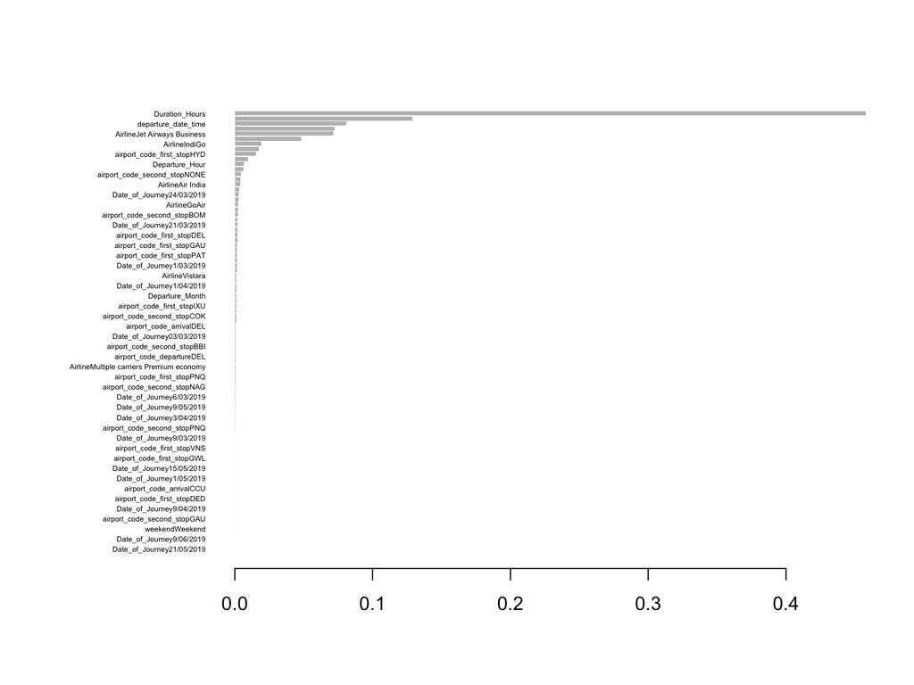

```r
xgb.plot.importance(importance_matrix)
```

### 4. Residual Analysis

This step helps to diagnose if there are any patterns in the model’s errors. We will use the predictions on the test dataset you made previously. This code assumes ‘predictions’ and ‘flight_data_test_processed’ are in your environment.

Get the actual prices from the test data

```r
actual_prices <- flight_data_test_processed$Price
```

Calculate the residuals (actuals minus predictions)

```r
residuals <- actual_prices - predictions
```

Create a data frame for plotting

```r
residuals_df <- data.frame(
  predictions = predictions,
  residuals = residuals
)
```

Create a scatter plot of predicted values vs. residuals

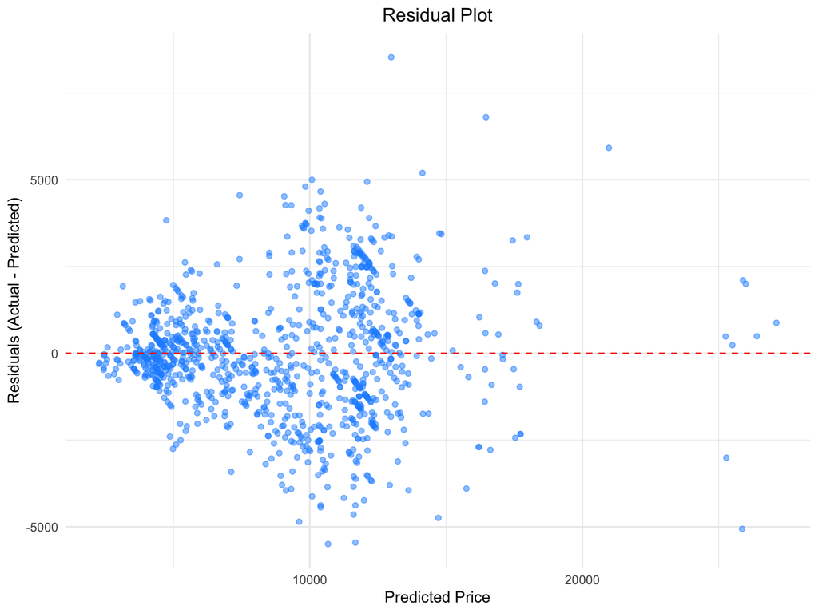

```r
ggplot(residuals_df, aes(x = predictions, y = residuals)) +
  geom_point(alpha = 0.5, color = "dodgerblue") +
  geom_hline(yintercept = 0, linetype = "dashed", color = "red") +
  labs(
    title = "Residual Plot",
    x = "Predicted Price",
    y = "Residuals (Actual - Predicted)"
  ) +
  theme_minimal() +
  theme(plot.title = element_text(hjust = 0.5))
```

## Gemini Summary

This output summarizes your trained XGBoost model. It confirms the model’s structure, the parameters used for training, and how its performance improved over the boosting iterations.

**Key Model Details**

The output provides a clear overview of the xgb.Booster object, which is the trained XGBoost model.

- # of features: 143: This confirms that the model was trained using 143 features. This is a crucial detail, as it matches the number of columns in your one-hot encoded training data matrix.
- niter: 200: The model was trained for 200 boosting rounds (nrounds). Each round adds a new decision tree to the model to correct the errors of the previous trees.
- nfeatures: 143: This is another check, confirming the number of features used to build the trees.

**Parameters Used for Training**

The params section lists the hyperparameters you defined for the model. These settings control the learning process and the structure of the trees.

- objective = “reg:squarederror”: This is the learning task. It tells the model to perform a regression and minimize the squared error between the predicted and actual values. This is appropriate for your task of predicting flight prices.
- eta = “0.1”: This is the learning rate. A smaller value, like 0.1, means the model takes smaller steps during each boosting round, which can lead to a more robust model that is less prone to overfitting.
- max_depth = “3”: This sets the maximum depth of each tree to 3. XGBoost uses many shallow trees rather than a few very deep ones, which helps prevent the model from becoming too complex and overfitting the training data.
- subsample = “0.8”: This means that for each boosting iteration, the model randomly samples 80% of the training data to build the new tree. This helps reduce variance and prevent overfitting.
- colsample_bytree = “0.8”: For each tree, the model randomly samples 80% of the features. This also helps to prevent overfitting by making the trees more diverse.

**Evaluation Log (train-rmse)**

The table shows the train-rmse (Root Mean Squared Error on the training data) at different iterations. It demonstrates how the model’s performance improved as more trees were added.

- iter: The iteration number (or boosting round).
- train-rmse: The RMSE calculated on the training data at that specific iteration.

1. **Cross-Validation Results**

The xgb.cv output shows how your model performs across different folds of your data.

- Training Performance (train-rmse-mean): The average training RMSE across the 5 folds starts at 9253 and steadily decreases, ending at 1751. This confirms the model is learning effectively.
- Validation Performance (test-rmse-mean): The average validation RMSE starts high but also decreases, ending at 1902. This is the most important number because it gives you a robust estimate of how well your model performs on truly unseen data.
- Overfitting: There is a small gap between the final training RMSE (1751) and the validation RMSE (1902). This indicates a slight degree of overfitting, which is normal. The model is performing slightly better on the data it has seen than on new data, but the difference is not a major concern.
2. **Feature Importance**

The feature importance chart and table are very insightful. They show you which features are most influential in predicting flight prices.

The residual plot is a key diagnostic tool.

**Overall Conclusion**

You’ve successfully built a reliable and well-validated predictive model.

# Regular Claude Response

For boosting in R, you’ll want to use the gbm package (Gradient Boosting Machine) or xgboost. Here are both approaches:

## Option 1: Boosted decision tree with gbm package

```r
library(gbm)
```

### Code Error: Data is having the same issue as before with the variables not being continuous

Going to go about it in a more manual way

```r
# Making sure all of the airport codes have the same numeric value

airport_code_bind <- flight_data_train_processed %>%
  mutate(id = row_number()) %>%
  select(id, airport_code_arrival, airport_code_departure,
          airport_code_first_stop, airport_code_second_stop,
          airport_code_third_stop) %>%
  pivot_longer(!id, names_to = "item", values_to = "response") %>%
  mutate(item = paste0(item, "_numeric"),
         response_numeric = as.numeric(as.factor(response))) %>%
  pivot_wider(id_cols = id, names_from = item, values_from = response_numeric)

flight_data_train_processed <- cbind(flight_data_train_processed, airport_code_bind)


flight_data_train_processed$Airline_numeric <- as.numeric(factor(
  flight_data_train_processed$Airline))

flight_data_train_processed$weekend_numeric <- as.numeric(factor(
  flight_data_train_processed$weekend))

flight_data_train_processed$departure_date_time_numeric <- as.numeric(flight_data_train_processed$departure_date_time)

flight_data_train_processed$arrival_date_time_numeric <- as.numeric(flight_data_train_processed$arrival_date_time)

flight_data_train_processed$Date_of_Journey_numeric <- as.numeric(as.factor(as.character(flight_data_train_processed$Date_of_Journey)))
```

```r
# Making sure all of the airport codes have the same numeric value

airport_code_bind <- flight_data_test_processed %>%
  mutate(id = row_number()) %>%
  select(id, airport_code_arrival, airport_code_departure,
          airport_code_first_stop, airport_code_second_stop,
          airport_code_third_stop) %>%
  pivot_longer(!id, names_to = "item", values_to = "response") %>%
  mutate(item = paste0(item, "_numeric"),
         response_numeric = as.numeric(as.factor(response))) %>%
  pivot_wider(id_cols = id, names_from = item, values_from = response_numeric)

flight_data_test_processed <- cbind(flight_data_test_processed, airport_code_bind)


flight_data_test_processed$Airline_numeric <- as.numeric(factor(
  flight_data_test_processed$Airline))

flight_data_test_processed$weekend_numeric <- as.numeric(factor(
  flight_data_test_processed$weekend))

flight_data_test_processed$departure_date_time_numeric <- as.numeric(flight_data_test_processed$departure_date_time)

flight_data_test_processed$arrival_date_time_numeric <- as.numeric(flight_data_test_processed$arrival_date_time)

flight_data_test_processed$Date_of_Journey_numeric <- as.numeric(as.factor(as.character(flight_data_test_processed$Date_of_Journey)))
```

```r
model_boosted_gbm <- gbm(
  Price ~ Departure_Day + Departure_Month + Departure_Hour +
          Duration_Hours + number_of_stops + weekend_numeric + Date_of_Journey_numeric +
          departure_date_time_numeric + arrival_date_time_numeric + Airline_numeric +
          airport_code_arrival_numeric + airport_code_departure_numeric +
          airport_code_first_stop_numeric + airport_code_second_stop_numeric +
          airport_code_third_stop_numeric,
  data = flight_data_train_processed,
  distribution = "gaussian",  # for regression (since you're predicting Price)
  n.trees = 1000,            # number of boosting iterations
  interaction.depth = 4,      # maximum depth of each tree
  shrinkage = 0.01,          # learning rate
  bag.fraction = 0.8,        # fraction of training data for each tree
  train.fraction = 1.0,      # fraction of data for training
  n.minobsinnode = 10,       # minimum observations in terminal nodes
  cv.folds = 5,              # cross-validation folds
  verbose = TRUE
)
```

Find optimal number of trees

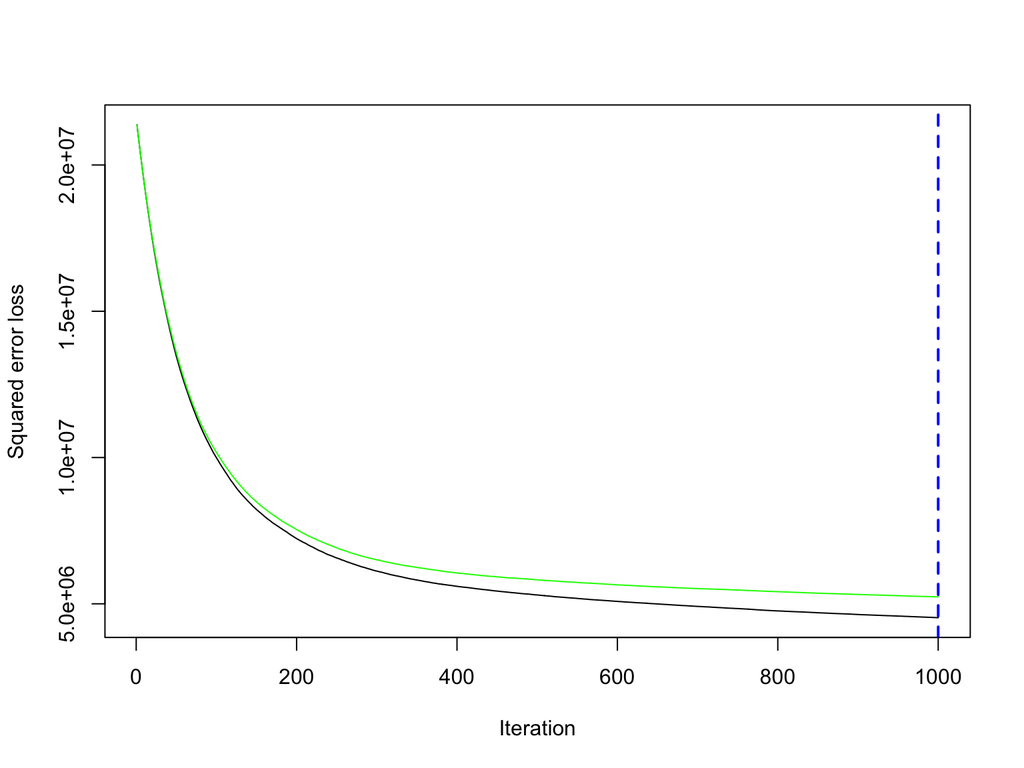

```r
best_iter_gbm <- gbm.perf(model_boosted_gbm, method = "cv")
```

```r
print(paste("Optimal number of trees (gbm):", best_iter_gbm))
```

```
[1] "Optimal number of trees (gbm): 1000"
```

Make predictions

```r
predictions_gbm <- predict(model_boosted_gbm,
                          newdata = flight_data_test_processed,
                          n.trees = best_iter_gbm)
```

Variable importance

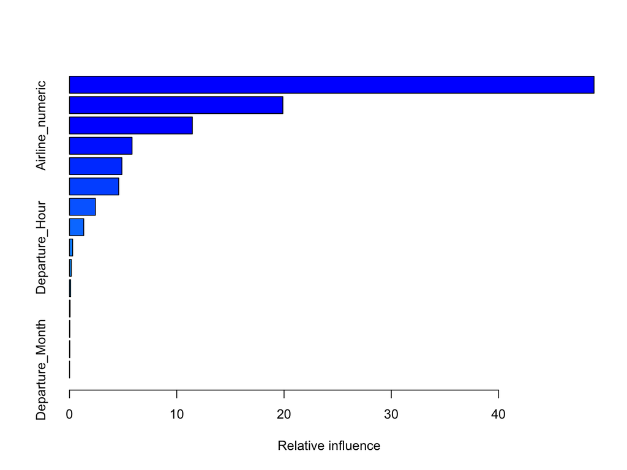

|  | var | rel.inf |
| --- | --- | --- |
| Duration_Hours | Duration_Hours | 48.904781097 |
| arrival_date_time_numeric | arrival_date_time_numeric | 19.890362177 |
| Airline_numeric | Airline_numeric | 11.454915455 |
| departure_date_time_numeric | departure_date_time_numeric | 5.830011935 |
| airport_code_second_stop_numeric | airport_code_second_stop_numeric | 4.885115082 |
| airport_code_first_stop_numeric | airport_code_first_stop_numeric | 4.588921323 |
| Date_of_Journey_numeric | Date_of_Journey_numeric | 2.415352555 |
| number_of_stops | number_of_stops | 1.328373142 |
| Departure_Hour | Departure_Hour | 0.294602544 |
| weekend_numeric | weekend_numeric | 0.167308206 |

[output cut: 5 more lines]

```r
summary(model_boosted_gbm, n.trees = best_iter_gbm)
```

## Option 1: BM Model Evaluation